# Practical Machine Learning

## Introduction:

This report describes the process that I used to build a machine learning algorithm for the John Hopkins Practical Machine Learning course.

The objective of the exercise is to predict the way in which a participant performed a Dumbbell Biceps Curl given the readings from a number of sensors. The researchers (Velloso, E.; Bulling, A.; Gellersen, H.; Ugulino, W.; Fuks, H. Qualitative Activity Recognition of Weight Lifting Exercises. Proceedings of 4th International Conference in Cooperation with SIGCHI (Augmented Human ’13) . Stuttgart, Germany: ACM SIGCHI, 2013.) collected training data from 6 participants where the curl was classified into one of the following classes:

- Class A: exactly according to the specification
- Class B: throwing the elbows to the front
- Class C: lifting the dumbbell only halfway
- Class D: lowering the dumbbell only halfway
- Class E: throwing the hips to the front

I have created a machine learning algorithm, trained on this data. The algorithm has then been used to predict the class of exercise of 20 different test cases.

## Study Design:

The training data provided consists of 19622 cases with 160 variables. I have partitioned this into three:

- A training data set used to train a variety of potential models. This will be 60% of the data.
- A test data set to compare the performance of the potential models and choose the final model. This will be 20% of the data.
- An evaluation data set to calculate the out of sample error. This will be 20% of the data.

## Data:

Data has been collected using 4 sensors attached to the participants glove, arm, belt and dumbbell.

Each sensor operates at 45Hz and records 9 different pieces of data:

- Gyros (x, y and z component)
- Accel (x, y and z component)
- magnet (x, y and z component)

From these 9 readings, 4 further values are calculated:

- Roll
- Pitch
- Yaw
- Total acceleration

The original researchers split these readings into windows and calculated features on these windows. For the purpose of my project these windows will not be used and the calculated features will be removed from the data set.

```r
  require(caret, quietly=TRUE)
  set.seed(1066)
  ## Load in the data:
  raw <- read.csv("http://d396qusza40orc.cloudfront.net/predmachlearn/pml-training.csv",
                  na.strings=c("NA", "#DIV/0!"),
                  stringsAsFactors = FALSE)
  raw$classe <- as.factor(raw$classe)
  ## Remove window features:
  raw_No_Windows <- raw[,colSums(is.na(raw)) < 1000]
  ## Remove variables related to data collection process:
  raw_Final <- raw_No_Windows[,8:60]

  ## Split into training, testing and evaluating partitions:
  inTrain <- createDataPartition(y=raw_Final$classe, p=0.6, list=FALSE)
  training <- raw_Final[inTrain,]
  testing <- raw_Final[-inTrain,]
  inEval <- createDataPartition(y=testing$classe, p=0.5, list=FALSE)
  eval <- testing[inEval,]
  testing <- testing[-inEval,]
```

## Model 1:

As a first model I have created a CART model using the rpart method using all predictor values:

```r
  model1 <- train(classe~., method = "rpart", data=training)
```

We can view the tree used in the final model:

```r
  require(rattle, quietly = TRUE)
```

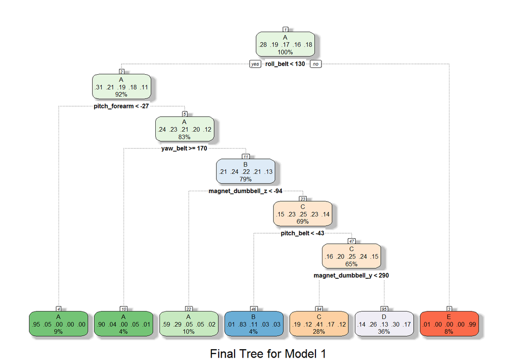

```r
  fancyRpartPlot(model1$finalModel, sub = "Final Tree for Model 1")
```

To assess the performance of model 1 we can calculate the confusion matrix of the testing data set:

```r
   confusionMatrix(predict(model1, testing), testing$classe)
```

```
## Confusion Matrix and Statistics
##
##           Reference
## Prediction   A   B   C   D   E
##          A 713 117  11  35  10
##          B   1 145  10   3   7
##          C 202 135 472 192 148
##          D 197 362 191 413 238
##          E   3   0   0   0 318
##
## Overall Statistics
##
##                Accuracy : 0.5254
##                  95% CI : (0.5096, 0.5411)
##     No Information Rate : 0.2845
##     P-Value [Acc > NIR] : < 2.2e-16
##
##                   Kappa : 0.4089
##  Mcnemar's Test P-Value : < 2.2e-16
##
## Statistics by Class:
##
##                      Class: A Class: B Class: C Class: D Class: E
## Sensitivity            0.6389  0.19104   0.6901   0.6423  0.44105
## Specificity            0.9384  0.99336   0.7910   0.6988  0.99906
## Pos Pred Value         0.8047  0.87349   0.4108   0.2948  0.99065
## Neg Pred Value         0.8673  0.83657   0.9236   0.9088  0.88812
## Prevalence             0.2845  0.19347   0.1744   0.1639  0.18379
## Detection Rate         0.1817  0.03696   0.1203   0.1053  0.08106
## Detection Prevalence   0.2258  0.04231   0.2929   0.3571  0.08183
## Balanced Accuracy      0.7886  0.59220   0.7405   0.6705  0.72006
```

The accuracy of the model on the testing data set is 0.5254 which is quite disappointing. Hopefully we can find a model with much better accuracy.

## Model 2:

Since the CART model did not have satisfactory accuracy, we can try a different approach to building a model. For the second model we will use a Random Forest:

```r
  ## The train function below is very slow, instead I will use a faster method:
  ## model2 <- train(classe~., method = "rf", data=training)
  require(randomForest, quietly = TRUE)
  model2 <- randomForest(classe~., data=training)
```

With so many features and a large training data set, I am conscious that this model might be over-fitted. Let’s check it’s performance on the testing data set:

```r
   confusionMatrix(predict(model2, testing), testing$classe)
```

```
## Confusion Matrix and Statistics
##
##           Reference
## Prediction    A    B    C    D    E
##          A 1116    3    0    0    0
##          B    0  751    1    0    0
##          C    0    5  683    7    3
##          D    0    0    0  635    3
##          E    0    0    0    1  715
##
## Overall Statistics
##
##                Accuracy : 0.9941
##                  95% CI : (0.9912, 0.9963)
##     No Information Rate : 0.2845
##     P-Value [Acc > NIR] : < 2.2e-16
##
##                   Kappa : 0.9926
##  Mcnemar's Test P-Value : NA
##
## Statistics by Class:
##
##                      Class: A Class: B Class: C Class: D Class: E
## Sensitivity            1.0000   0.9895   0.9985   0.9876   0.9917
## Specificity            0.9989   0.9997   0.9954   0.9991   0.9997
## Pos Pred Value         0.9973   0.9987   0.9785   0.9953   0.9986
## Neg Pred Value         1.0000   0.9975   0.9997   0.9976   0.9981
## Prevalence             0.2845   0.1935   0.1744   0.1639   0.1838
## Detection Rate         0.2845   0.1914   0.1741   0.1619   0.1823
## Detection Prevalence   0.2852   0.1917   0.1779   0.1626   0.1825
## Balanced Accuracy      0.9995   0.9946   0.9970   0.9933   0.9957
```

The accuracy of the model on the testing data set is 0.9941. this is remarkably good.

We can check the importance of the different variables in the model:

```r
  vImportance <- varImp(model2, scale = TRUE)
  vImportance
```

```
##                        Overall
## roll_belt            775.13012
## pitch_belt           410.25689
## yaw_belt             533.31021
## total_accel_belt     136.51242
## gyros_belt_x          59.41467
## gyros_belt_y          68.12291
## gyros_belt_z         192.05091
## accel_belt_x          72.51465
## accel_belt_y          77.36137
## accel_belt_z         255.71342
## magnet_belt_x        146.03248
## magnet_belt_y        216.11994
## magnet_belt_z        227.74375
## roll_arm             187.01701
## pitch_arm            106.05053
## yaw_arm              149.89091
## total_accel_arm       61.64998
## gyros_arm_x           84.04593
## gyros_arm_y           84.64272
## gyros_arm_z           37.87756
## accel_arm_x          138.50174
## accel_arm_y           86.99515
## accel_arm_z           78.46104
## magnet_arm_x         151.13523
## magnet_arm_y         124.95043
## magnet_arm_z         111.49612
## roll_dumbbell        251.02631
## pitch_dumbbell       103.43685
## yaw_dumbbell         159.06131
## total_accel_dumbbell 154.95903
## gyros_dumbbell_x      74.07151
## gyros_dumbbell_y     146.43234
## gyros_dumbbell_z      53.23937
## accel_dumbbell_x     159.95904
## accel_dumbbell_y     243.74170
## accel_dumbbell_z     202.31901
## magnet_dumbbell_x    282.54805
## magnet_dumbbell_y    410.33989
## magnet_dumbbell_z    444.14075
## roll_forearm         362.61741
## pitch_forearm        454.15885
## yaw_forearm          106.49785
## total_accel_forearm   70.52873
## gyros_forearm_x       45.12510
## gyros_forearm_y       77.06590
## gyros_forearm_z       51.10377
## accel_forearm_x      206.18819
## accel_forearm_y       86.84386
## accel_forearm_z      143.20836
## magnet_forearm_x     138.92570
## magnet_forearm_y     133.47925
## magnet_forearm_z     176.09744
```

Plotting graphs using pairs of the most important variables can help us to observe structure to the data:

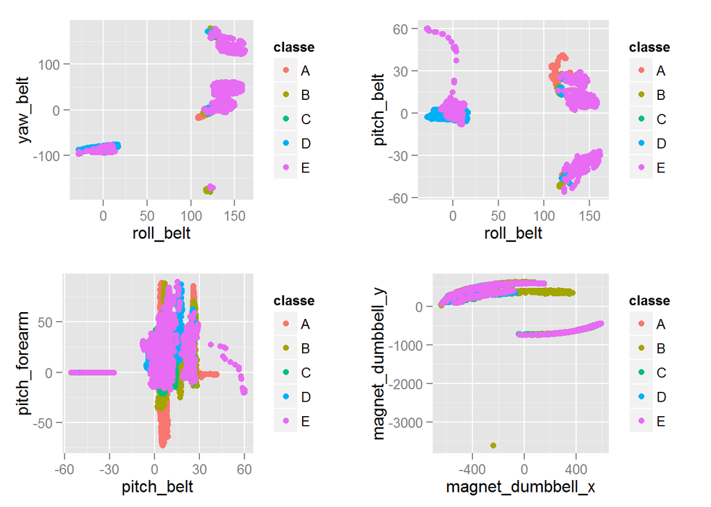

```r
  require(ggplot2)
  require(gridExtra)
  p1 <- qplot(roll_belt, yaw_belt,
              color=classe, data=training)
  p2 <- qplot(roll_belt, pitch_belt,
              color=classe, data=training)
  p3 <- qplot(pitch_belt, pitch_forearm,
              color=classe, data=training)
  p4 <- qplot(magnet_dumbbell_x, magnet_dumbbell_y,
              color=classe, data=training)
  grid.arrange(p1,p2,p3,p4, ncol=2)
```

We can see from the graphs that there is a structure to the data. Data points of the same type appear to form multiple overlapping clusters. This may be why the CART model was not accurate but the random forest is.

## Models 3 and 4:

It will be easier to understand our model if it uses fewer variables without compromising accuracy.

```r
  model3 <- randomForest(classe~roll_belt
                         +yaw_belt
                         +pitch_forearm
                         +magnet_dumbbell_z
                         +pitch_belt
                         , data=training)
  model4 <- randomForest(classe~roll_belt
                         +yaw_belt
                         +pitch_forearm
                         +magnet_dumbbell_z
                         +pitch_belt
                         +magnet_dumbbell_y
                         +roll_forearm
                         +magnet_dumbbell_x
                         +roll_dumbbell
                         +accel_dumbbell_y
                         , data=training)
```

We can compare the accuracy of these models to model 2:

```r
  confusionMatrix(predict(model2, testing), testing$classe)$overall
```

```
##       Accuracy          Kappa  AccuracyLower  AccuracyUpper   AccuracyNull
##      0.9941371      0.9925838      0.9912157      0.9962799      0.2844762
## AccuracyPValue  McnemarPValue
##      0.0000000            NaN
```

```r
  confusionMatrix(predict(model3, testing), testing$classe)$overall
```

```
##       Accuracy          Kappa  AccuracyLower  AccuracyUpper   AccuracyNull
##   9.699210e-01   9.619591e-01   9.640863e-01   9.750409e-01   2.844762e-01
## AccuracyPValue  McnemarPValue
##   0.000000e+00   2.578147e-05
```

```r
  confusionMatrix(predict(model4, testing), testing$classe)$overall
```

```
##       Accuracy          Kappa  AccuracyLower  AccuracyUpper   AccuracyNull
##      0.9834310      0.9790435      0.9789297      0.9871898      0.2844762
## AccuracyPValue  McnemarPValue
##      0.0000000            NaN
```

There is quite a significant reduction in accuracy compared to model 2. Although these are simpler models I don’t think this trade-off is worthwhile when we are trying to accurately predict all 20 test cases for this project.

## Final Model:

I am going to use model 2 as my final model. It is exceptionally accurate on the testing data set.

Had this model not been so accurate I would have considered different methods (for example using boosting or combining predictors) and also using preprocessing on the data set to create better features.

Let’s check the final model on our evaluation data set to get a final estimate for the out of sample error rate:

```r
  confusionMatrix(predict(model2, eval), eval$classe)
```

```
## Confusion Matrix and Statistics
##
##           Reference
## Prediction    A    B    C    D    E
##          A 1115    8    0    0    0
##          B    1  747    3    0    0
##          C    0    4  681    7    0
##          D    0    0    0  634    1
##          E    0    0    0    2  720
##
## Overall Statistics
##
##                Accuracy : 0.9934
##                  95% CI : (0.9903, 0.9957)
##     No Information Rate : 0.2845
##     P-Value [Acc > NIR] : < 2.2e-16
##
##                   Kappa : 0.9916
##  Mcnemar's Test P-Value : NA
##
## Statistics by Class:
##
##                      Class: A Class: B Class: C Class: D Class: E
## Sensitivity            0.9991   0.9842   0.9956   0.9860   0.9986
## Specificity            0.9971   0.9987   0.9966   0.9997   0.9994
## Pos Pred Value         0.9929   0.9947   0.9841   0.9984   0.9972
## Neg Pred Value         0.9996   0.9962   0.9991   0.9973   0.9997
## Prevalence             0.2845   0.1935   0.1744   0.1639   0.1838
## Detection Rate         0.2842   0.1904   0.1736   0.1616   0.1835
## Detection Prevalence   0.2863   0.1914   0.1764   0.1619   0.1840
## Balanced Accuracy      0.9981   0.9915   0.9961   0.9928   0.9990
```

The out of sample accuracy is 99.3%.

## Submitting Prediction Results:

Using this final model I have predicted and submitted the output from the 20 test cases. For reasons of space the code for this is not included - it can be found in the instructions provided by the instructor.

All predictions using the model were correct. I consider the project to have been successful.

## Final Remarks:

I am somewhat uneasy about this project. Although impressed with the accuracy of the random forest method I am skeptical that class of activity can be predicted with such accuracy from instantaneous sensor readings. I would be interested to see video footage of the data collection process and see if the 5 classes of exercise were performed in exaggeratedly different manners. While this would allow for good results from the machine learning algorithm it would make the results less generalizable to real world situation.

## References:

Velloso, E.; Bulling, A.; Gellersen, H.; Ugulino, W.; Fuks, H. Qualitative Activity Recognition of Weight Lifting Exercises. Proceedings of 4th International Conference in Cooperation with SIGCHI (Augmented Human ’13) . Stuttgart, Germany: ACM SIGCHI, 2013. http://groupware.les.inf.puc-rio.br/har